# IS 4487 Lab 11

## Learning Objective

Use Linear Regression to predict the AQI in Utah.

## Outline

- Pull the latest "Daily AQI by County" file from this link: https://aqs.epa.gov/aqsweb/airdata/download_files.html#AQI
- Your target variable will be *AQI", which is the value of the air quality index
- We will focus the analysis on only the air quality in the state of Utah.
- Note that there is a several-month lag in preparing data; you should check to see if your file has a full year of data from January to December. If not, use the previous year.
- The AQI is divided into six categories:

*Air Quality Index*

| (AQI) Values | Levels of Health Concern |
| --- | --- |
| 0-50 | Good |
| 51-100 | Moderate |
| 101-150 | Unhealthy for Sensitive Groups |
| 151 to 200 | Unhealthy |
| 201 to 300 | Very Unhealthy |
| 301 to 500 | Hazardous |

## Load Libraries

➡️ Assignment Tasks

- Load any necessary libraries

```python
import pandas as pd
import matplotlib as mpl
import seaborn as sns

from sklearn.tree import DecisionTreeClassifier, export_graphviz # Import Decision Tree Classifier
from sklearn.model_selection import train_test_split # Import train_test_split function
from sklearn import metrics  #Import scikit-learn metrics module for accuracy calculation
from sklearn.metrics import confusion_matrix, precision_score, recall_score, f1_score, classification_report
```

```python
from google.colab import files
uploaded = files.upload()
```

Upload widget is only available when the cell has been executed in the current browser session. Please rerun this cell to enable.

```
Saving daily_aqi_by_county_2024 2.csv to daily_aqi_by_county_2024 2.csv
```

## Import Data into Dataframe

➡️ Assignment Tasks

- Pull the latest full year of data using the "Daily AQI by County" files from this link: https://aqs.epa.gov/aqsweb/airdata/download_files.html#AQI
- Make sure to UNZIP the file
- Import data from the air quality dataset into a dataframe
- Describe or profile the dataframe

```python
df = pd.read_csv('daily_aqi_by_county_2024 2.csv')
print(df)
```

```
       State Name county Name  State Code  County Code        Date  AQI  \
0         Alabama     Baldwin           1            3  2024-01-03   41
1         Alabama     Baldwin           1            3  2024-01-04   38
2         Alabama     Baldwin           1            3  2024-01-05   44
3         Alabama     Baldwin           1            3  2024-01-06    7
4         Alabama     Baldwin           1            3  2024-01-07   29
...           ...         ...         ...          ...         ...  ...
206914    Wyoming      Weston          56           45  2024-06-26   45
206915    Wyoming      Weston          56           45  2024-06-27   48
206916    Wyoming      Weston          56           45  2024-06-28   47
206917    Wyoming      Weston          56           45  2024-06-29   37
206918    Wyoming      Weston          56           45  2024-06-30   47

       Category Defining Parameter Defining Site  Number of Sites Reporting
0          Good              PM2.5   01-003-0010                          1
1          Good              PM2.5   01-003-0010                          1
2          Good              PM2.5   01-003-0010                          1
3          Good              PM2.5   01-003-0010                          1
4          Good              PM2.5   01-003-0010                          1
...         ...                ...           ...                        ...
206914     Good              Ozone   56-045-0003                          1
206915     Good              Ozone   56-045-0003                          1
206916     Good              Ozone   56-045-0003                          1
206917     Good              Ozone   56-045-0003                          1
206918     Good              Ozone   56-045-0003                          1

[206919 rows x 10 columns]
```

## Prepare Data

➡️ Assignment Tasks

- Filter the data to use Utah data only
- Create one dummy variable (true/false) for each of the Defining Parameter values
- Create variables for month of year, year, and season
- Perform any other data cleanup needed (remove outliers, nulls, etc.)
- After filtering for Utah, remove the geographical variables that remain (county, state) since those non-numeric values can't be used. Remove any other non-numeric variables.
- Select the data you would like to use in the model. If you aggregate data, you will have to decide whether to use the min, max or mean value for AQI
- Split the data 80/20 for training and testing

```python
#filter for Utah data only
df_utah = df[df['State Name'] == 'Utah']

# Display the first few rows of the filtered data
df_utah.head()
```

|  | State Name | county Name | State Code | County Code | Date | AQI | Category | Defining Parameter | Defining Site | Number of Sites Reporting |
| --- | --- | --- | --- | --- | --- | --- | --- | --- | --- | --- |
| 178824 | Utah | Box Elder | 49 | 3 | 2024-01-01 | 71 | Moderate | PM2.5 | 49-003-0005 | 2 |
| 178825 | Utah | Box Elder | 49 | 3 | 2024-01-02 | 64 | Moderate | PM2.5 | 49-003-0005 | 2 |
| 178826 | Utah | Box Elder | 49 | 3 | 2024-01-03 | 66 | Moderate | PM2.5 | 49-003-0005 | 2 |
| 178827 | Utah | Box Elder | 49 | 3 | 2024-01-04 | 60 | Moderate | PM2.5 | 49-003-0005 | 2 |
| 178828 | Utah | Box Elder | 49 | 3 | 2024-01-05 | 29 | Good | Ozone | 49-003-7001 | 2 |

```python
df_utah.info()
```

```
<class 'pandas.core.frame.DataFrame'>
Index: 4206 entries, 178824 to 183029
Data columns (total 10 columns):
 #   Column                     Non-Null Count  Dtype
---  ------                     --------------  -----
 0   State Name                 4206 non-null   object
 1   county Name                4206 non-null   object
 2   State Code                 4206 non-null   int64
 3   County Code                4206 non-null   int64
 4   Date                       4206 non-null   object
 5   AQI                        4206 non-null   int64
 6   Category                   4206 non-null   object
 7   Defining Parameter         4206 non-null   object
 8   Defining Site              4206 non-null   object
 9   Number of Sites Reporting  4206 non-null   int64
dtypes: int64(4), object(6)
memory usage: 490.5+ KB
```

```python
df_utah.describe()
```

|  | State Code | County Code | AQI | Number of Sites Reporting |
| --- | --- | --- | --- | --- |
| count | 4206.0 | 4206.000000 | 4206.000000 | 4206.000000 |
| mean | 49.0 | 29.262007 | 50.285307 | 1.798859 |
| std | 0.0 | 18.994181 | 19.103658 | 2.008652 |
| min | 49.0 | 3.000000 | 2.000000 | 1.000000 |
| 25% | 49.0 | 11.000000 | 40.000000 | 1.000000 |
| 50% | 49.0 | 35.000000 | 46.000000 | 1.000000 |
| 75% | 49.0 | 47.000000 | 58.000000 | 2.000000 |
| max | 49.0 | 57.000000 | 230.000000 | 9.000000 |

```python
#create columns
df_utah['Date'] = pd.to_datetime(df['Date'])

# Create dummy variables for 'Defining Parameter'
df_utah = pd.get_dummies(df, columns=['Defining Parameter'], dtype=bool)

df_utah['Date'] = pd.to_datetime(df['Date'], errors='coerce')
df_utah = df_utah.dropna(subset=['Date'])
# Extract Year and Month
df_utah['Year'] = df_utah['Date'].dt.year
df_utah['Month'] = df_utah['Date'].dt.month
```

```python
# Define seasons
def get_season(month):
    if month in [12, 1, 2]:
        return 'Winter'
    elif month in [3, 4, 5]:
        return 'Spring'
    elif month in [6, 7, 8]:
        return 'Summer'
    else:
        return 'Fall'

df_utah['Season'] = df_utah['Month'].apply(get_season)

# Categorize AQI into health concern levels
def categorize_aqi(aqi):
    if 0 <= aqi <= 50:
        return 'Good'
    elif 51 <= aqi <= 100:
        return 'Moderate'
    elif 101 <= aqi <= 150:
        return 'Unhealthy for Sensitive Groups'
    elif 151 <= aqi <= 200:
        return 'Unhealthy'
    elif 201 <= aqi <= 300:
        return 'Very Unhealthy'
    else:
        return 'Hazardous'

df_utah['AQI_Category'] = df_utah['AQI'].apply(categorize_aqi)

# Display first few rows
df_utah.head()
```

|  | State Name | county Name | State Code | County Code | Date | AQI | Category | Defining Site | Number of Sites Reporting | Defining Parameter_CO | Defining Parameter_NO2 | Defining Parameter_Ozone | Defining Parameter_PM10 | Defining Parameter_PM2.5 | Year | Month | Season | AQI_Category |
| --- | --- | --- | --- | --- | --- | --- | --- | --- | --- | --- | --- | --- | --- | --- | --- | --- | --- | --- |
| 0 | Alabama | Baldwin | 1 | 3 | 2024-01-03 | 41 | Good | 01-003-0010 | 1 | False | False | False | False | True | 2024 | 1 | Winter | Good |
| 1 | Alabama | Baldwin | 1 | 3 | 2024-01-04 | 38 | Good | 01-003-0010 | 1 | False | False | False | False | True | 2024 | 1 | Winter | Good |
| 2 | Alabama | Baldwin | 1 | 3 | 2024-01-05 | 44 | Good | 01-003-0010 | 1 | False | False | False | False | True | 2024 | 1 | Winter | Good |
| 3 | Alabama | Baldwin | 1 | 3 | 2024-01-06 | 7 | Good | 01-003-0010 | 1 | False | False | False | False | True | 2024 | 1 | Winter | Good |
| 4 | Alabama | Baldwin | 1 | 3 | 2024-01-07 | 29 | Good | 01-003-0010 | 1 | False | False | False | False | True | 2024 | 1 | Winter | Good |

```python
#data cleanup
df_utah = df_utah.dropna()
```

```python
#select final columns for use
# Drop geographical and other non-numeric variables
df_utah = df_utah.drop(columns=['county Name', 'State Code', 'County Code', 'Defining Site', 'Category'])

# Select final numeric columns
final_columns = ['Date', 'AQI', 'Year', 'Month', 'Season']

# Add dummy variables for 'Defining Parameter'
dummy_columns = [col for col in df_utah.columns if 'Defining Parameter_' in col]
final_columns.extend(dummy_columns)

# Create final dataframe with only numeric and useful categorical variables
df_utah_final = df_utah[final_columns]

# Display first few rows
df_utah_final.head()
```

|  | Date | AQI | Year | Month | Season | Defining Parameter_CO | Defining Parameter_NO2 | Defining Parameter_Ozone | Defining Parameter_PM10 | Defining Parameter_PM2.5 |
| --- | --- | --- | --- | --- | --- | --- | --- | --- | --- | --- |
| 0 | 2024-01-03 | 41 | 2024 | 1 | Winter | False | False | False | False | True |
| 1 | 2024-01-04 | 38 | 2024 | 1 | Winter | False | False | False | False | True |
| 2 | 2024-01-05 | 44 | 2024 | 1 | Winter | False | False | False | False | True |
| 3 | 2024-01-06 | 7 | 2024 | 1 | Winter | False | False | False | False | True |
| 4 | 2024-01-07 | 29 | 2024 | 1 | Winter | False | False | False | False | True |

```python
#split the data into training and testing datasets
# Define features (X) and target variable (y)
X = df_utah_final.drop(columns=['AQI', 'Date'])  # Features (excluding AQI and Date)
y = df_utah_final['AQI']  # Target variable (AQI)

# Split the data into training (80%) and testing (20%) sets
X_train, X_test, y_train, y_test = train_test_split(X, y, test_size=0.2, random_state=42)

# Display the shape of the datasets
X_train.shape, X_test.shape, y_train.shape, y_test.shape
```

```
((165535, 8), (41384, 8), (165535,), (41384,))
```

## Create Model

➡️ Assignment Tasks

- Create a simple linear regression to predict AQI based on as many variables as you can use or derive. (for example, sklearn LinearRegression)
- Evaluate the model by displaying the R squared value
- Visualize the correlation between the target variable and at least one of the independent variables

```python
from sklearn.preprocessing import OneHotEncoder
from sklearn.compose import ColumnTransformer
from sklearn.pipeline import Pipeline
from sklearn.linear_model import LinearRegression
from sklearn.metrics import mean_squared_error, r2_score

#create regression or classification model
X_train, X_test, y_train, y_test = train_test_split(X, y, test_size=0.2, random_state=42)

# Initialize the linear regression model
preprocessor = ColumnTransformer(
    transformers=[
        ('season', OneHotEncoder(), ['Season'])  # OneHotEncoding for categorical 'Season' column
    ],
    remainder='passthrough'  # Leave other columns as is
)

# Create a pipeline that first applies preprocessing and then fits the model
model_pipeline = Pipeline(steps=[
    ('preprocessor', preprocessor),
    ('regressor', LinearRegression())
])
# Train the model
model_pipeline.fit(X_train, y_train)

# Predict on the test set
y_pred = model_pipeline.predict(X_test)
```

```python
#print the R squared value
mse = mean_squared_error(y_test, y_pred)
r2 = r2_score(y_test, y_pred)
print(f"R-squared: {r2:.2f}")
```

```
R-squared: 0.07
```

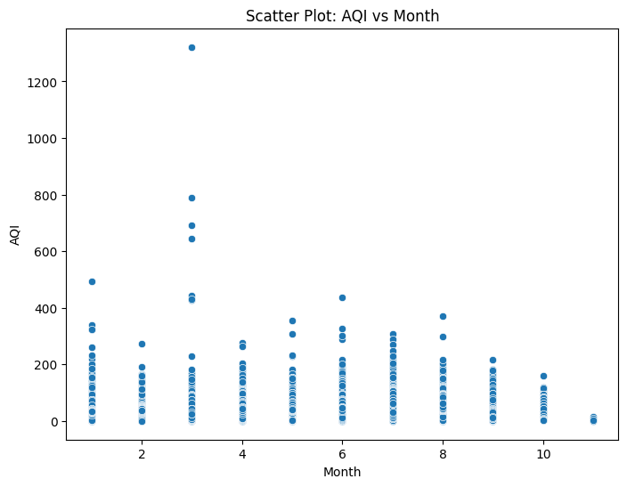

```
Correlation between AQI and Month: 0.16
```

```python
#visual
import matplotlib.pyplot as plt
independent_variable = 'Month'

# Calculate the correlation between AQI and the chosen independent variable
correlation = df_utah_final['AQI'].corr(df_utah_final[independent_variable])

# Plotting a scatter plot
plt.figure(figsize=(8, 6))
sns.scatterplot(x=df_utah_final[independent_variable], y=df_utah_final['AQI'])
plt.title(f"Scatter Plot: AQI vs {independent_variable}")
plt.xlabel(independent_variable)
plt.ylabel('AQI')
plt.show()

# Display the correlation coefficient
print(f"Correlation between AQI and {independent_variable}: {correlation:.2f}")
```

## Make a prediction

➡️ Assignment Tasks

- What would you predict the average AQI to be in January of the upcoming year?

```python
#predicted AQI
# January (month = 1)
df_january = df_utah_final[df_utah_final['Month'] == 1]

# Ensure the features are prepared for prediction (same as training data)
X_january = df_january.drop(columns=['AQI', 'Date'])

# Use the trained model to predict AQI for January
y_january_pred = model_pipeline.predict(X_january)

# Compute the average predicted AQI for January
average_aqi_january = y_january_pred.mean()

# Print the result
print(f"Predicted average AQI for January of the upcoming year: {average_aqi_january:.2f}")
```

```
Predicted average AQI for January of the upcoming year: 36.26
```

## OPTIONAL: Compare Air Quality

➡️ Assignment Tasks

- Download the data from several previous years using this website: https://aqs.epa.gov/aqsweb/airdata/download_files.html#AQI
- Append the new data to the previous dataframe
- Use the year as a variable in your regression. Is year a significant factor in predicting AQI?

```python
#import, append and create new model
```